# Introduction

This vignett is a part of USF project in Clark University, and we want to answer to the question “Are Neighborhoods with Public Housing Projects Brighter?” using Providence RI as a case study.

# Datasets

Here is a list of datasets that will be used

- Artificial Light at Night (ALAN) Radiance Data from [NASA](https://www.earthdata.nasa.gov/learn/backgrounders/nighttime-lights)
- NDVI in May 2023 from [Landsat8](https://www.usgs.gov/landsat-missions/landsat-8)
- Population Data in 2020 from [Census Data](https://www.census.gov)
- Public Housing Data updated in 2023 from [HUD](https://www.huduser.gov/portal/datasets/assthsg.html#2009-2022_data)
- Building Footprint Data from [RI GIS Portal](https://www.rigis.org/datasets/building-footprints)

# Workflow

This study will follow [a previous study](https://github.com/agroimpacts/USFlite/blob/main/external/notebooks/nightlights-part2.md) done by Dr. Estes et al at Clark University, and this will:

1. Plotting rasters of the variables
2. Exploring relations between the ALAN radiance and the other variables using scatter plot and linear regression line
3. Comparing medians of the ALAN radiance from cells, which have similar population, between with/ without public housings after

Additionally, I will try if we can estimate the ALAN radiance from population, public housing density size, and NDVI with a superivized machine learning method.

# Analysis

## Plot

The below is short descriptions about every plots. Note that:

- the ALAN and the building density have similar patterns, and they are concentrated in center.
- the NDVI and the above two layers have opposite patterns, high NDVI areas are surrounding the city center.
- the population grids and the ALAN show partially overlap, but the population have concentrations in the southwest.
- the public housing layer are not evenly distributed to the whole city: they are in west and north- central

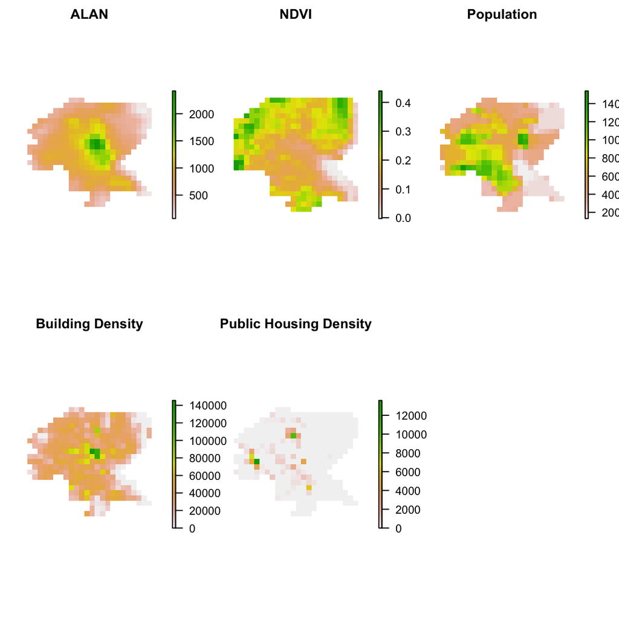

```r
titles <- c("ALAN", "NDVI", "Population", "Building Density", "Public Housing Density")
plot_noaxes(b, main = titles)
```

## Scatter Plot and Regression Line

The scatter and regression plots were similar with what I expected to have. I got positive correlation between the ALAN radiance and the population & the building density. Especially, the building density has an extremely strong relations with the ALAN. I would say the correlation between the public housing and the alan is random or very weak. On the other hand, the alan and the NDVI have apparently negative correlations.

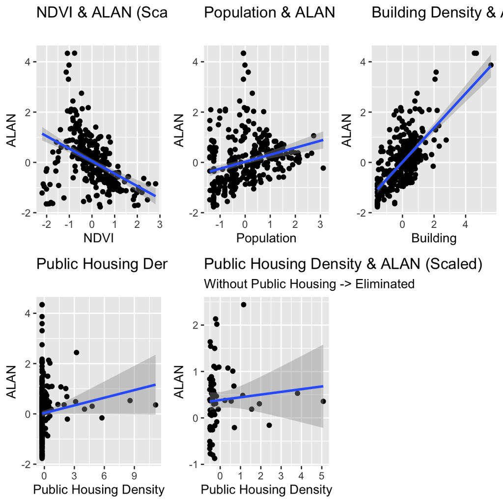

```r
g1 <- p %>% ggplot() + # creating plot from ggplot2
  geom_point(aes(x = ndvi, y = alan)) + # adding scatter plot # putting ndvi on x & alan on y
  geom_smooth(aes(x = ndvi, y = alan), method = "lm") + # adding lm line
  xlab("NDVI") + ylab("ALAN")+ # adding xlabel & ylabel
  ggtitle("NDVI & ALAN (Scaled)") # adding main title

g2 <- p %>% ggplot() + # creating another plot # for a cow plot
  geom_point(aes(x = pop, y = alan)) + # using population as a variable
  geom_smooth(aes(x = pop, y = alan), method = "lm") +
  xlab("Population") + ylab("ALAN")+
  ggtitle("Population & ALAN (Scaled)")

g3 <- p %>% ggplot() + # creating another plot # for a cow plot
  geom_point(aes(x = bld, y = alan)) + # using building density as a variable
  geom_smooth(aes(x = bld, y = alan), method = "lm") +
  xlab("Building") + ylab("ALAN")+
  ggtitle("Building Density & ALAN (Scaled)")

g4 <- p %>% ggplot() + # creating another plot # for a cow plot
  geom_point(aes(x = ph_area, y = alan)) + # using ph as a variable
  geom_smooth(aes(x = ph_area, y = alan), method = "lm") +
  xlab("Public Housing Density")+ ylab("ALAN")+
  ggtitle("Public Housing Density & ALAN (Scaled)")

g5 <- p_ph %>% ggplot() + # creating the last plot # for a cow plot # using sf with ph only
  geom_point(aes(x = ph_area, y = alan)) + # using ph as a variable
  geom_smooth(aes(x = ph_area, y = alan), method = "lm") +
  xlab("Public Housing Density") + ylab("ALAN")+
  ggtitle("Public Housing Density & ALAN (Scaled)",
         subtitle = "Without Public Housing -> Eliminated") # adding subtitle

cowplot::plot_grid(g1, g2, g3, g4, g5, # using the 3 plots
                   nrow = 2, # with 3 rows
                   align = "vh", # vertically & horizontally alligned
                   axis = "l") # aligned to left
```

## Median Comparison

To do this, I will compare night light radiance of population class between grids with PH and without. To be specific:

1. Assigning quantiles (every 20%)
2. Assigning Ph status
3. Comparing the grids using boxplot.

Additionally, I will calculate the strict medians. Note the values were scaled so that they are not the “real.”

As a result, the median of night time radiance from grids with public housings were higher 4 out of the 5 classes, although population level2 looks too small for the those with public housings.

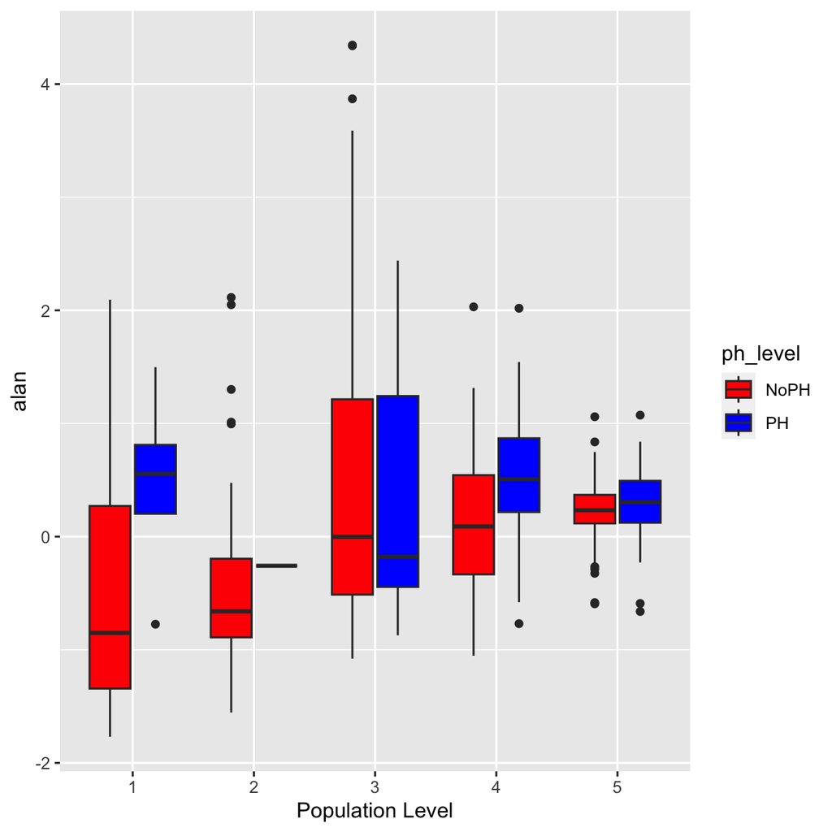

```r
# Assigning the quantiles----
pop_q <- p %>%
  pull(pop) %>% # using pop column
  quantile(., # calculating quantile
           probs = seq(0, 1, 0.2)) # making class every 20 percentiles

df <- st_drop_geometry(p) %>% as.data.frame()

df <- df %>%
  mutate(pop_class = ifelse(pop < pop_q[2], 1,
                 ifelse(pop < pop_q[3], 2,
                 ifelse(pop < pop_q[4], 3,
                 ifelse(pop < pop_q[5], 4, 5)))) %>%
           as.factor()
)

# Assigning ph status----
df <- df %>%
  mutate(ph_level = ifelse(ph_area > -0.2218275, "PH", "NoPH")) # adding a columns showing ph status

# Creating box plots----
df %>%
  ggplot() + geom_boxplot(aes(x = pop_class, # putting pop level on x
                              y = alan, # putting radiance on y
                              fill = ph_level)) + # dividing by ph_status
  xlab("Population Level") + # adding x label
  scale_fill_manual(values = c("red", "blue")) # adding colors
```

```r
df %>%
  group_by(ph_level, pop_class) %>% # grouping by ph level and population quantile
  summarize(Radiance = median(alan)) %>% # calculating medians
  pivot_wider(names_from = ph_level, values_from = Radiance) %>% # adding columns for comparison
  mutate(Difference = PH - NoPH) %>%
  rename(PopulationClass = pop_class) %>%
  print()
```

```
## # A tibble: 5 × 4
##   PopulationClass     NoPH     PH Difference
##   <fct>              <dbl>  <dbl>      <dbl>
## 1 1               -0.851    0.555     1.41
## 2 2               -0.661   -0.258     0.403
## 3 3               -0.00205 -0.179    -0.176
## 4 4                0.0897   0.507     0.417
## 5 5                0.233    0.304     0.0712
```

##Cross Tab Map of ALAN, Population & Public Housing

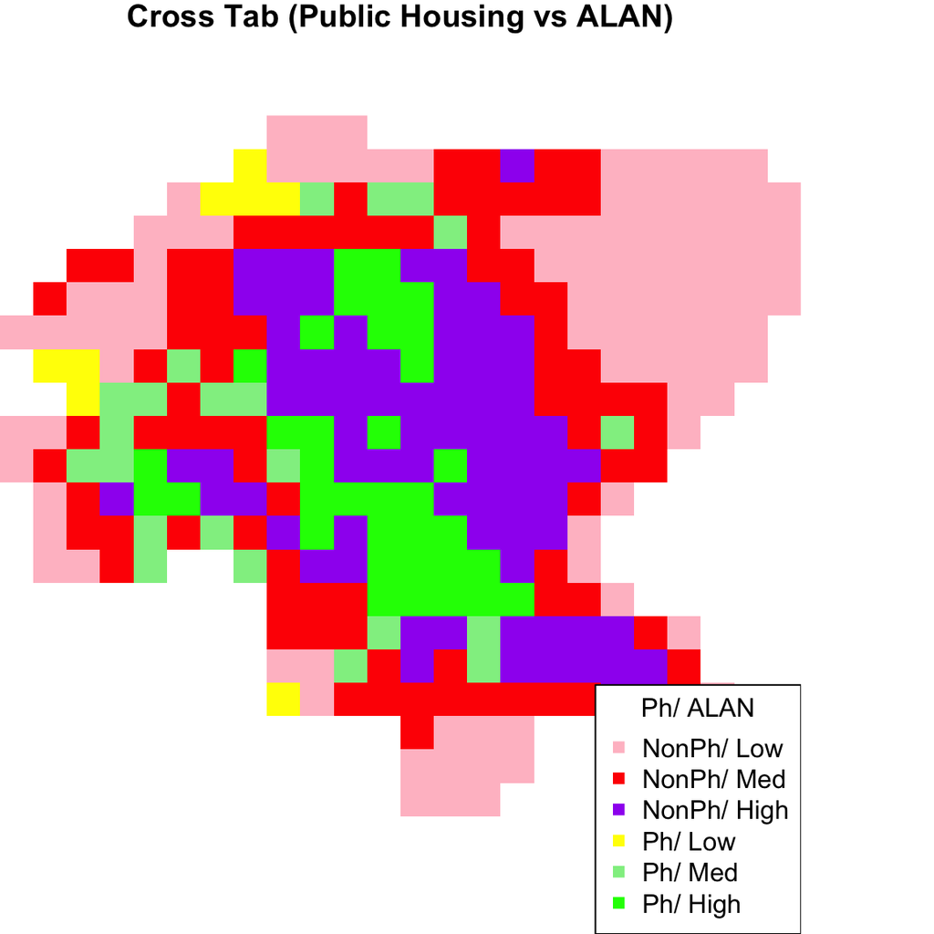

```r
# Converting Raster to Polygon====
p_reclass <- b %>%
  rasterToPolygons() %>% # conversion
  st_as_sf() %>%
  na.omit(.) %>% # removing na
  select(alan = layer.1,
         ndvi = layer.2,
         pop = layer.3,
         bld = layer.4,
         ph = layer.5)

# Reclassifying Values====
# Population----
pop_level <- p_reclass %>%
  pull(pop) %>%
  quantile(.,
           probs = seq(0, 1, 0.33)) # putting quantiles every 33 percentiles

light_level <- p_reclass %>%
  pull(alan) %>%
  quantile(.,
           probs = seq(0, 1, 0.33))

# Applying to values----
p_reclass <- p_reclass %>%
  mutate(pop_class = ifelse(pop < pop_level[2], 1, # if lower than the first block # assigning 1
                     ifelse(pop < pop_level[3], 2, 3)) %>% # if not and if lower than the second blocks # assigning 2 # otherwise assigning 3
           as.character(), # converting into character # for concatnation
         alan_class = ifelse(alan < light_level[2], 1,
                      ifelse(alan < light_level[3], 2, 3)) %>%
           as.character(),
         ph_class = ifelse(ph > 0, 2, 1) %>% # if having ph # assigning 1
           as.character(),
         alan_ph = paste0(ph_class,alan_class) %>% # creating final class from concatnation
           as.integer(),
         alan_pop = paste0(pop_class, alan_class) %>%
           as.integer())

alan_ph_raster <- rasterize(p_reclass,
                            b,
                            field = "alan_ph")
rec <- cbind(sort(unique(p_reclass$ alan_ph)-1), # creating reclassification matrix: from # sort for reordering # unique for distinction
             sort(unique(p_reclass$ alan_ph)), # creating reclass mtx "To"
             1:length(unique(p_reclass$ alan_ph))) # assigning new categorical values by counting the number of categories

alan_ph_class <- reclassify(x = alan_ph_raster, # reclassifying the lightph_crstbr
                            rcl = rec, # by using the reclassification mtx
                            include.lowest = TRUE) # including the floor values in each class

col <- c("pink", "red", "purple", "yellow", "lightgreen", "green")
class <- c("NonPh/ Low", "NonPh/ Med", "NonPh/ High", "Ph/ Low", "Ph/ Med", "Ph/ High")
plot_noaxes(alan_ph_class, # protting the crosstab raster
            legend = F, # without default legend
            main = "Cross Tab (Public Housing vs ALAN)",  # inserting a title
            col = col, # using the color palette
            mar = c(0, 0, 1, 0)) # inserting margin

legend(x = "bottomright", # inserting a legend topleft
       legend = class, # inserting legend classes
       pch = 15, # shape of the legends
       pt.cex = 1, # size of the legend
       col = col, # using the color palette
       bty = "o", # with a bounding box
       title = "Ph/ ALAN") # adding legend title
```

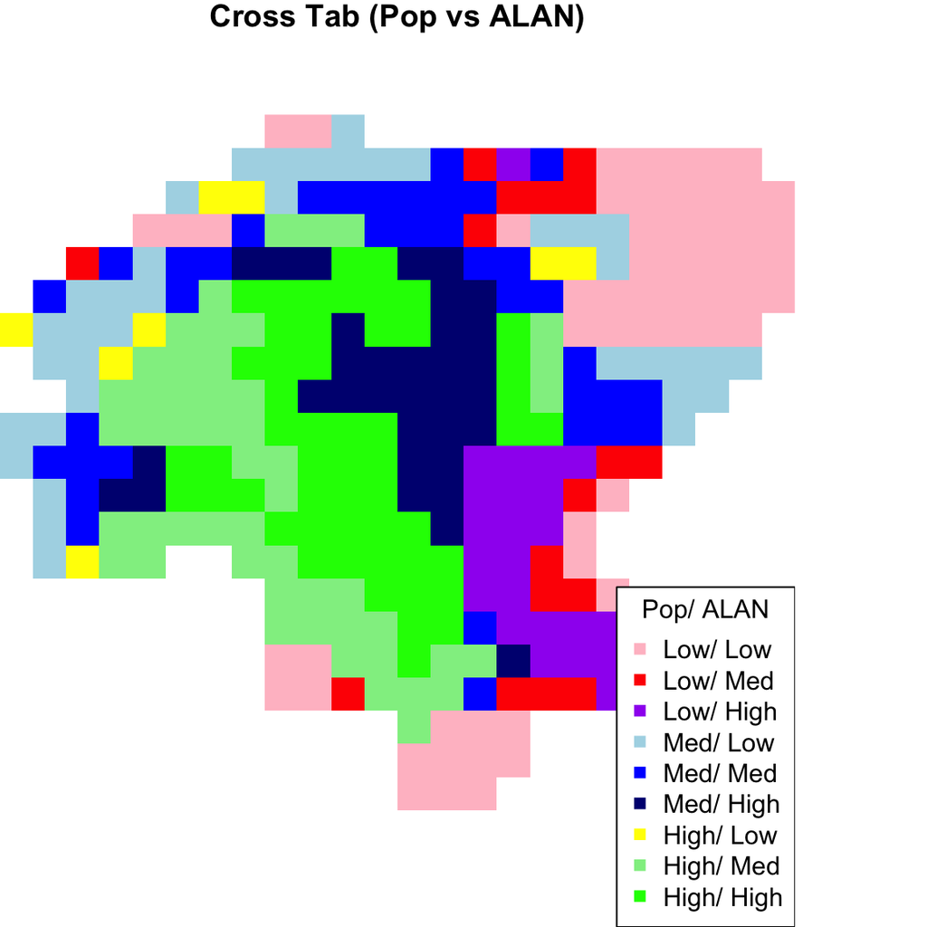

```r
alan_pop_raster <- rasterize(p_reclass,
                             b,
                             field = "alan_pop")

rec <- cbind(sort(unique(p_reclass$ alan_pop)-1), # creating reclassification matrix: from # sort for reordering # unique for distinction
             sort(unique(p_reclass$ alan_pop)), # creating reclass mtx "To"
             1:length(unique(p_reclass$ alan_pop))) # assigning new categorical values by counting the number of categories

alan_pop_class <- reclassify(x = alan_pop_raster, # reclassifying the lightph_crstbr
                            rcl = rec, # by using the reclassification mtx
                            include.lowest = TRUE) # including the floor values in each class

col <- c("pink", "red", "purple", "lightblue", "blue", "navy","yellow", "lightgreen", "green")
class <- c("Low/ Low", "Low/ Med", "Low/ High", "Med/ Low", "Med/ Med", "Med/ High", "High/ Low", "High/ Med", "High/ High")

plot_noaxes(alan_pop_class, # protting the crosstab raster
            legend = F, # without default legend
            main = "Cross Tab (Pop vs ALAN)",  # inserting a title
            col = col, # using the color palette
            mar = c(0, 0, 1, 0)) # inserting margin

legend(x = "bottomright", # inserting a legend topleft
       legend = class, # inserting legend classes
       pch = 15, # shape of the legends
       pt.cex = 1, # size of the legend
       col = col, # using the color palette
       bty = "o", # with a bounding box
       title = "Pop/ ALAN") # adding legend title
```

# Prediction of the ALAN Class